# ITSxpress maxEE22 vs maxEE88

QC20 paired-end ITS2 — maxEE sensitivity and taxonomic classification

2026-10-15

# 1 1. Dataset 및 object 차이

- ITSxpress와 QC20을 고정하고 DADA2 maxEE 2/2와 8/8만 비교함.
- abundance filtering, singleton removal, rarefaction 및 decontam은 적용하지 않음.
- 각 object의 실제 fungal sample과 ASV를 먼저 확인하고, paired 통계와 beta diversity는 두 object에 공통으로 존재하는 SampleID만 사용함.

| maxEE | Samples | Fungal_ASVs | Total_Fungal_Reads | Method_Only_Samples | Common_Samples |
| --- | --- | --- | --- | --- | --- |
| maxEE22 | 83 | 1215 | 536398 | 0 | 83 |
| maxEE88 | 83 | 1221 | 541963 | 0 | 83 |

# 2 2. Sample별 read 및 observed ASV

| Metric | N_Pairs | Median_maxEE22 | Median_maxEE88 | P_value | P_adjust_BH |
| --- | --- | --- | --- | --- | --- |
| Read depth | 83 | 6692 | 6804 | 1.159024663801886e-12 | 2.318049327603772e-12 |
| Observed ASV | 83 | 44 | 44 | 0.1199521429616278 | 0.1199521429616278 |

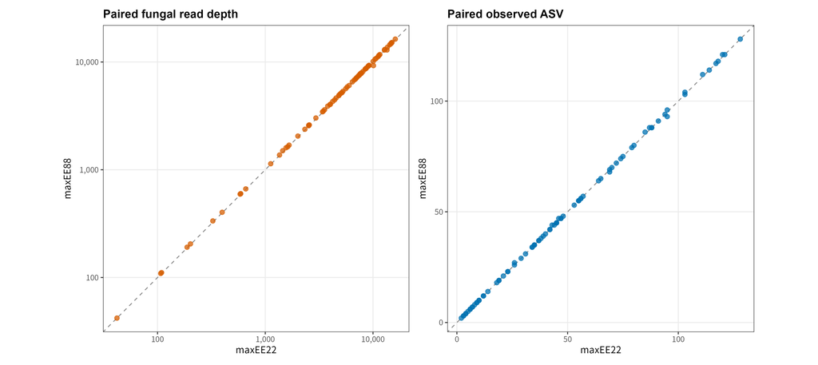

# 3 3. Exact ASV sequence 및 taxonomy 안정성

| Item | N_or_fraction |
| --- | --- |
| maxEE22 fungal ASVs | 1215 |
| maxEE88 fungal ASVs | 1221 |
| Exact shared ASVs | 1215 |
| maxEE22-only ASVs | 0 |
| maxEE88-only ASVs | 6 |
| maxEE22 reads in shared ASVs | 1 |
| maxEE88 reads in shared ASVs | 0.9997841181040034 |
| Shared sequences with different cleaned taxonomy | 0 |

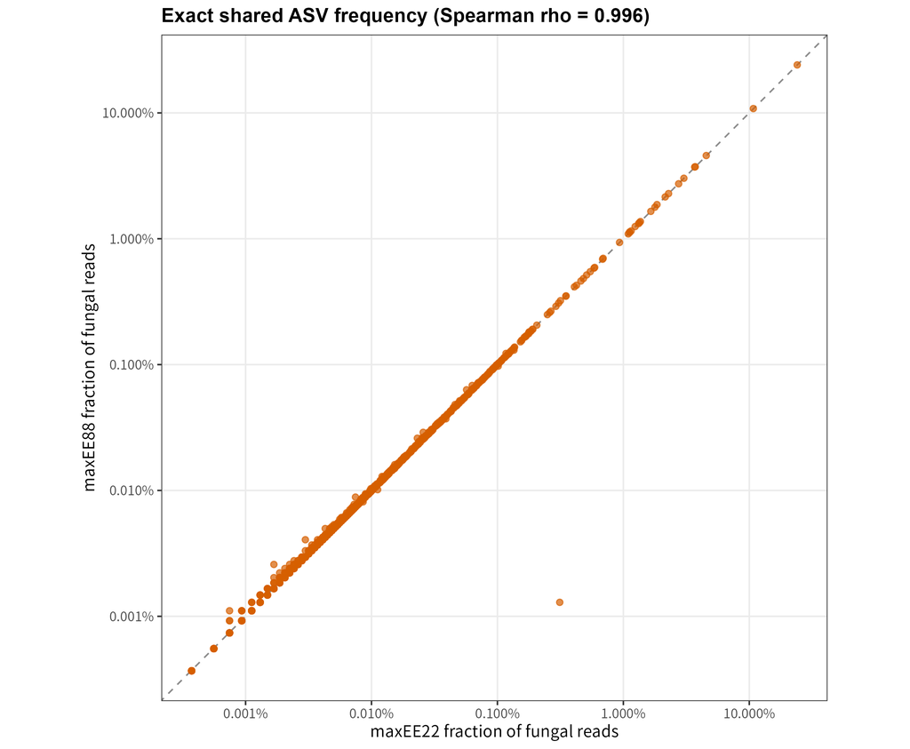

| Status | N_ASV | Total_Reads | Median_Reads | Single_Sample_ASVs | Median_Length |
| --- | --- | --- | --- | --- | --- |
| maxEE88 only | 6 | 117 | 17 | 6 | 186.5 |

| Status | FeatureID | Length | Reads | Prevalence | Species |
| --- | --- | --- | --- | --- | --- |
| maxEE88 only | 13a098ff49c1d45ab5f4c02db1a08172 | 148 | 46 | 1 | Ascomycota p |
| maxEE88 only | 10df5dda6da738d76d1e812f100e9846 | 291 | 28 | 1 | Malassezia sp |
| maxEE88 only | 79361244d060515557a523e3dad75b55 | 274 | 26 | 1 | Malassezia restricta |
| maxEE88 only | 72e1ff96dfd688e857b0425006bd5a0b | 205 | 8 | 1 | Agaricomycetes sp |
| maxEE88 only | 658c75be48c43528d234ab9cb4061c81 | 149 | 5 | 1 | Phaeosphaeria oryzae |
| maxEE88 only | 380cd3a7d604b4858e5871d9f88f6b09 | 168 | 4 | 1 | Hypocreales o |

# 4 4. Species 검출 및 abundance 차이

| Detection_Status | N_Species |
| --- | --- |
| Shared | 598 |

| Species | N_Pairs | Mean_maxEE22 | Mean_maxEE88 | Mean_Difference_88_minus_22 | P_value | P_adjust_BH | Significant |
| --- | --- | --- | --- | --- | --- | --- | --- |
| Nigrospora sp | 83 | 0.02855867512008716 | 0.02837056443847529 | -0.0001881106816118717 | 0.0002999495716388831 | 0.004199294002944364 | ** |
| Rhodotorula mucilaginosa | 83 | 0.04374217618120342 | 0.04423018343909087 | 0.0004880072578874464 | 0.0006013262533522208 | 0.004209283773465546 | ** |
| Cladosporium g | 83 | 0.01931577875547104 | 0.01931688167003406 | 1.102914563030281e-06 | 0.01299770347763334 | 0.06065594956228894 | ns |
| Cutaneotrichosporon debeurmannianum | 83 | 0.0735867225576379 | 0.07402807877226304 | 0.0004413562146251359 | 0.02106416828862868 | 0.07372458901020038 | ns |
| Malassezia restricta | 83 | 0.3787070227140068 | 0.3787277792409134 | 2.075652690665219e-05 | 0.02856014803862317 | 0.07996841450814486 | ns |
| Fungi sp | 83 | 0.03337327997576819 | 0.03199303815463549 | -0.001380241821132692 | 0.1251711332051631 | 0.263426198052316 | ns |
| Ascomycota p | 83 | 0.02405379739993744 | 0.02410459594358724 | 5.079854364979337e-05 | 0.131713099026158 | 0.263426198052316 | ns |
| Alternaria g | 83 | 0.0328200999755612 | 0.0327701055968992 | -4.999437866200009e-05 | 0.2313766035277262 | 0.4049090561735208 | ns |
| Malassezia globosa | 83 | 0.03752159603216798 | 0.03755870210125499 | 3.710606908700252e-05 | 0.2940327566451936 | 0.4503011887709068 | ns |
| Pleosporales sp | 83 | 0.01669701166224822 | 0.01674126196262863 | 4.425030038040653e-05 | 0.3216437062649334 | 0.4503011887709068 | ns |

[output cut: 4 more lines]

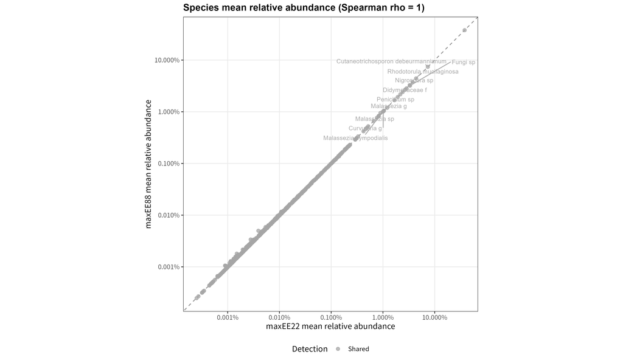

| Species | Reads_maxEE22 | Reads_maxEE88 | Prevalence_maxEE22 | Prevalence_maxEE88 | Mean_maxEE22 | Mean_maxEE88 | Detection_Status | Mean_Difference_88_minus_22 | Combined_Mean |
| --- | --- | --- | --- | --- | --- | --- | --- | --- | --- |

# 5 5. Aitchison PCoA 및 paired maxEE effect

| Distance | N_Samples | PERMANOVA_R2 | PERMANOVA_P | Betadisper_P | Procrustes_Correlation | PROTEST_P |
| --- | --- | --- | --- | --- | --- | --- |
| Aitchison (Species CLR, pseudocount 0.5) | 83 | 6.62930978276273e-06 | 0.001 | 0.945 | 0.9998803912091178 | 0.001 |

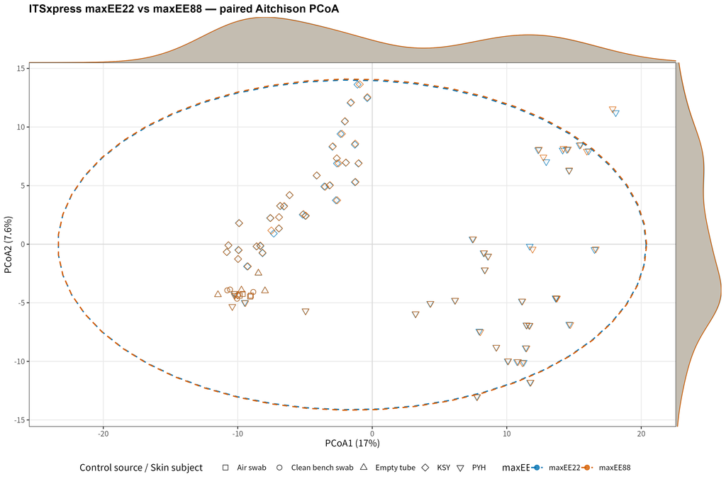

# 6 6. SampleID별 Species composition

### 6.0.1 maxEE22

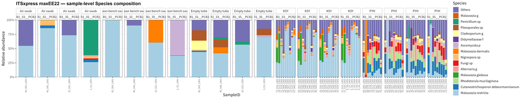

maxEE22 고해상도 PNG 원본

### 6.0.2 maxEE88

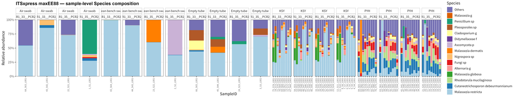

maxEE88 고해상도 PNG 원본

# 7 7. 결론

- 두 ITSxpress object의 공통 sample은 83개임.
- fungal ASV는 maxEE22 1215개, maxEE88 1221개임.
- exact shared ASV는 1215개이며 maxEE22 reads의 100.0%, maxEE88 reads의 100.0%를 설명함.
- 동일 sequence에서 cleaned taxonomy가 달라진 경우는 0개임.
- condition-specific Species는 maxEE22-only 0개, maxEE88-only 0개임.
- maxEE88-only ASV 6개는 총 117 reads이며 모두 단일 sample에서만 관찰됨. 이 ASV들이 추가한 새 Species label은 없음.
- Aitchison PERMANOVA maxEE effect R2는 6.63e-06, p-value는 0.001임. p-value와 별개로 설명력은 사실상 0에 가까움.
- Procrustes correlation은 1, PROTEST p-value는 0.001임.

# 8 8. 해석 한계

- condition-specific ASV 또는 Species는 biological absence가 아니라 낮은 abundance, DADA2 error model 및 read retention 차이로 detection boundary를 넘나든 결과일 수 있음.
- 동일 sequence의 taxonomy가 일치하면 maxEE에 따른 분류기 자체의 변화가 아니라, 해당 sequence의 검출 여부가 달라진 것임.
- paired Wilcoxon은 maxEE parameter effect를 탐색하기 위한 분석이며 독립 biological group의 differential abundance 검정으로 해석하지 않음.
- Aitchison 분석은 rarefaction 없이 수행했으며 pseudocount 0.5를 사용함.